# The Housing Exclusion Index: Machine Learning Reveals America’s Most Restrictive Places

Census Monkey Typewriter

2025-07-24

# The Housing Exclusion Paradox

Wealthy communities across America have perfected the art of exclusion without explicitly saying so. Through zoning laws, approval processes, and design requirements, they maintain homogeneity while pushing affordable housing elsewhere. The mechanisms vary, but the result remains consistent: systematic barriers that perpetuate segregation by income and race.

Where are these exclusionary practices most entrenched? Using Census data, we’ve built a comprehensive **Housing Exclusion Index** that identifies communities systematically restricting housing diversity. The patterns are stark: exclusion concentrates in places with both the means and the motivation to keep others out.

## The Anatomy of Housing Exclusion

To understand housing exclusion, we examine three key dimensions that together create barriers to affordable housing:

**Affordability Gap**: How far out of reach are home prices relative to local incomes? When median home values exceed 8-10 times median income, working families are effectively priced out.

**New Construction Rate**: How much new housing is being built? Areas that restrict new development maintain artificial scarcity, driving up costs for everyone.

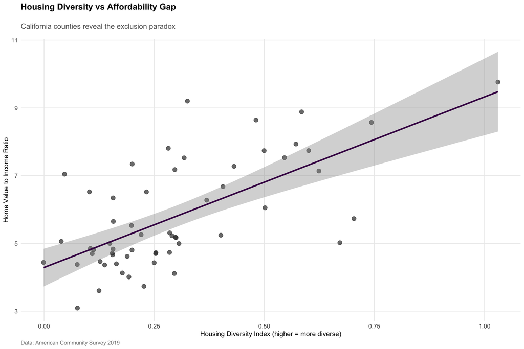

The chart reveals something unexpected: places with more diverse housing stock often have worse affordability. Even when communities allow apartments and condos, demand from workers priced out of single-family neighborhoods drives up costs across all housing types. Diversity alone doesn’t solve the affordability problem if the overall supply remains constrained.

## The Geography of Exclusion

[figure not shown]

The map tells a familiar story with new precision. Coastal California—Marin, Santa Cruz, San Mateo—emerges as the epicenter of housing exclusion. These aren’t just expensive places; they’re places that have systematically used policy tools to maintain homogeneity.

But the analysis also reveals surprises. Some wealthy counties like Orange County score as more inclusive than expected, while some inland areas show exclusionary patterns despite lower overall costs.

## The Exclusion Hall of Fame

California’s Most Exclusionary Counties

| County | Exclusion Score | Housing Diversity | Affordability Gap | New Construction Rate |
| --- | --- | --- | --- | --- |
| San Francisco | 5.59 | 1.03 | 9.8 | 0.04 |
| Los Angeles | 4.48 | 0.74 | 8.6 | 0.02 |
| Marin | 3.99 | 0.48 | 8.6 | 0.01 |
| Santa Cruz | 3.37 | 0.33 | 9.2 | 0.02 |
| Mono | 3.34 | 0.67 | 5.0 | 0.00 |
| San Mateo | 3.28 | 0.58 | 8.9 | 0.03 |
| Alpine | 2.85 | 0.70 | 5.7 | 0.02 |
| Alameda | 2.63 | 0.60 | 7.7 | 0.03 |
| Monterey | 2.12 | 0.43 | 7.3 | 0.02 |
| San Diego | 1.95 | 0.62 | 7.1 | 0.04 |

## The Inclusive Alternatives

California’s Most Inclusive Counties

| County | Exclusion Score | Housing Diversity | Affordability Gap | New Construction Rate |
| --- | --- | --- | --- | --- |
| Riverside | -1.77 | 0.29 | 5.2 | 0.05 |
| Glenn | -1.88 | 0.25 | 4.7 | 0.04 |
| Yuba | -2.18 | 0.25 | 4.4 | 0.04 |
| Imperial | -2.29 | 0.30 | 4.1 | 0.05 |
| Madera | -2.56 | 0.14 | 4.4 | 0.04 |
| Fresno | -2.57 | 0.25 | 4.7 | 0.05 |
| Kern | -2.75 | 0.19 | 4.0 | 0.05 |
| Kings | -2.98 | 0.23 | 3.7 | 0.05 |
| Placer | -3.11 | 0.22 | 5.3 | 0.06 |
| Tulare | -3.30 | 0.18 | 4.1 | 0.05 |

## The Policy Implications

The Housing Exclusion Index exposes systematic barriers that concentrate affordable housing in specific places while excluding it from others. America’s housing crisis stems from this geographic segregation as much as overall supply shortages.

**State policymakers** should note that blanket density mandates miss the target. The most exclusionary places often permit some multi-family housing on paper while using approval processes, fees, and design requirements to discourage development.

**Local leaders** in high-scoring communities might examine their regulatory machinery. Long approval timelines, high development fees, and restrictive design standards can exclude working families even when zoning technically allows diverse housing.

**Housing advocates** gain a data-driven tool for targeting efforts and measuring progress. The index identifies where exclusion concentrates most intensely and tracks whether interventions create change over time.

## Beyond California: The National Picture

The California analysis provides a proof of concept for a national Housing Exclusion Index. Scaling this methodology to all 3,000+ U.S. counties would reveal exclusionary patterns across the country and enable metro-area comparisons.

## The Path Forward

Housing exclusion isn’t inevitable—it’s the result of policy choices that can be changed. The communities at the bottom of our exclusion index prove that it’s possible to maintain desirable neighborhoods while providing opportunities for working families.

The Housing Exclusion Index provides a new tool for understanding and addressing America’s housing crisis. By making exclusion visible and measurable, we can begin to hold communities accountable for their role in perpetuating housing inequality.

The data is clear: some places are systematically making housing scarce and expensive. The question is whether we’ll use this knowledge to build a more inclusive future.

*Analysis based on American Community Survey 2019 data. Code and methodology available at github.com/census-monkey-typewriter. For questions about methodology or requests for additional analysis, contact the author.*